# PPARa and Liver Fibrosis

Nyssa Tucker

2023-05-31

# 1 Goal

SE/SA PPAR(alpha) q

PPAR(alpha) as a usecase knowing PPARa activation leads to fibrosis.

Use ExEmPLAR to ID hepatic specific markers (as opposed to broad PPARa cascade)

# 2 Steps

_1 JMB rationalized / substantiated PPARalpha activation as leading to fibrosis, capturing relevant cascade.

_2 Consider how specific hepatic processes interplay

_3 for NNT –> counterfactual of ppara leading to other diseases (AT rec)

# 3 Output

## 3.1 1 Initiating Narrative

SA query to demo RK usage.  
SE met w SA in feb/march 2023 and decided to focus in PPAR studies.  
We all met on the 13th of April and discussed.

AT tasked me and JMB w collab here.  
AT tasked me with counterfacutal PPAR diseases and JMB with targeted fibrotic pathway recovery via RK.

## 3.2 2 JMB

JMB initial results: powerpoint NNT git.

SE emphasized specific interest in path in liver specific modulating factors:

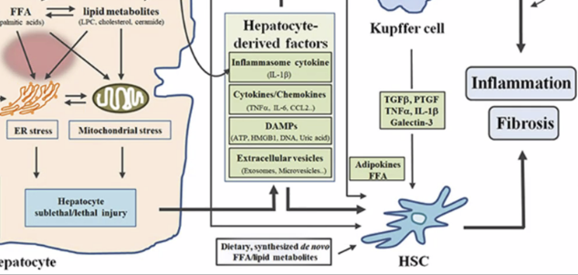

.

JMB captured left hand box, but not center or right factors.

## 3.3 3 NNT

I am working on two distinct tracts here. First, AT suggestion of PPARA : all diseases.  
PPARA : UniProtKB:Q07869

[Second](https://docs.google.com/presentation/d/1hnJ_d4zUrfUhhVFD9E1RA1t5Do6jY0d4grY_Src7Qec/edit?usp=sharing) is the link between ppara or fatty acids and fibrosis. FA: MESH:D005227

| path | max_esnd | node0 | edge0 | node1 | edge1 | node2 | edge2 | node3 |
| --- | --- | --- | --- | --- | --- | --- | --- | --- |
| P1 | 89 | PPARA | enables | transcription coregulator binding | enables | JUND | genetic association | Hepatic fibrosis |
| P1 | 96 | PPARA | enables | nuclear receptor activity | contributes to | ARNT | genetic association | Hepatic fibrosis |
| P1 | 115 | PPARA | enables | transcription coregulator binding | enables | NFE2L2 | genetic association | Hepatic fibrosis |
| P1 | 171 | PPARA | acts upstream of | negative regulation of cytokine production involved in inflammatory response | actively involved in | F2 | genetic association | Hepatic fibrosis |
| P1 | 196 | PPARA | actively involved in | regulation of protein binding | actively involved in | VTN | genetic association | Hepatic fibrosis |
| P1 | 196 | PPARA | actively involved in | negative regulation of defense response | actively involved in | CNR2 | genetic association | Hepatic fibrosis |

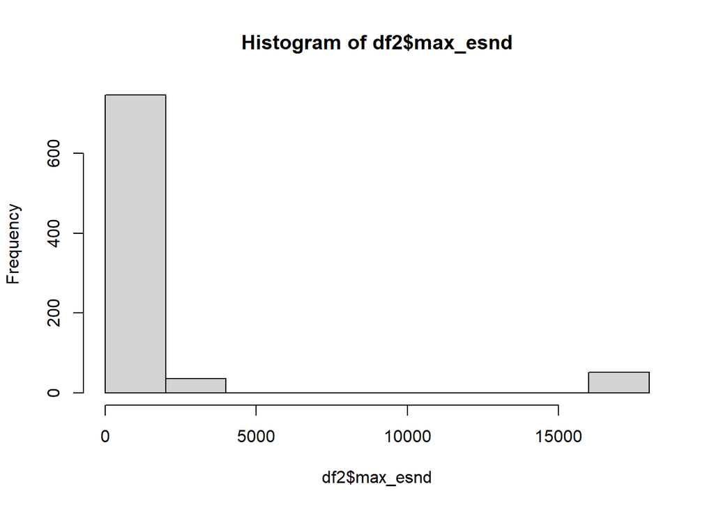

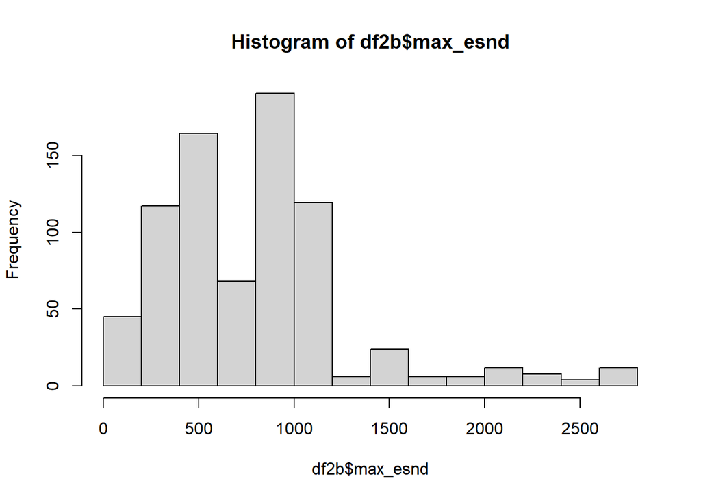

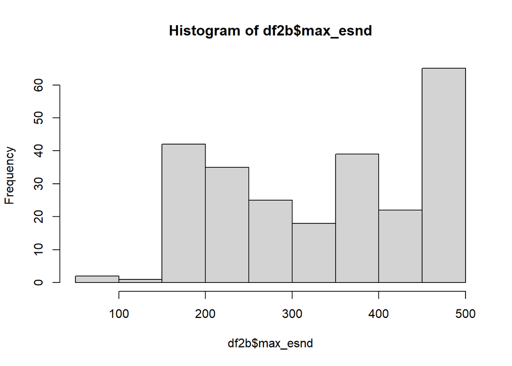

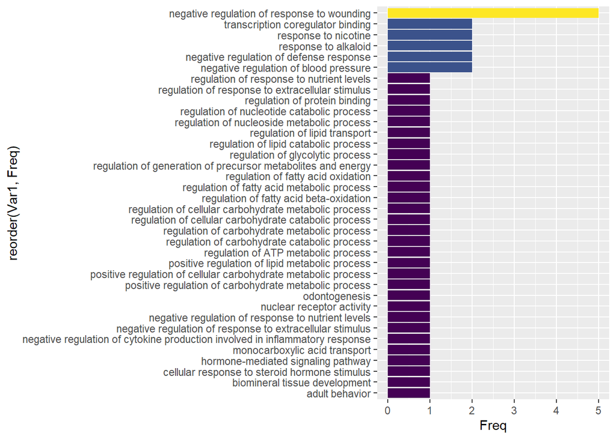

```
## [1] 157
```

```
##   [1] negative regulation of defense response
##   [2] protein binding
##   [3] regulation of defense response
##   [4] regulation of inflammatory response
##   [5] regulation of response to external stimulus
##   [6] regulation of response to wounding
##   [7] response to wounding
##   [8] wound healing
##   [9] anion transport
##  [10] carboxylic acid transport
##  [11] cellular lipid metabolic process
##  [12] cellular response to lipid
##  [13] cellular response to organic cyclic compound
##  [14] lipid localization
##  [15] lipid transport
```

[output cut: 143 more lines]

```
##  [1] A2M      ABCB4    ACTA2    ADRA1A   AGT      ALAD     ARNT     ARRB1
##  [9] C1QB     CCL2     CCN2     CD9      CHRM3    CNR1     CNR2     COL1A2
## [17] COL3A1   COMMD1   CP       CTNNB1   CYBA     CYP27A1  F2       FBN1
## [25] FGF2     FGF7     FGFR2    FLT1     GC       HDAC2    HGF      IFNA13
## [33] IGFBP2   IL6      JUND     KRT18    KRT8     LAMC2    LGALS1   LGALS3BP
## [41] LOX      MMP2     NFE2L2   NPC1     PCOLCE   PLAU     PLOD2    REN
## [49] RGN      SERPINA1 SERPINA6 SERPINH1 SLC13A4  SLC17A2  SPARC    SPP1
## [57] TAGLN2   TGFB1    THBS1    TMEM67   VEGFA    VIM      VTN
## 63 Levels: A2M ABCB4 ACTA2 ADRA1A AGT ALAD ARNT ARRB1 C1QB CCL2 CCN2 ... VTN
```

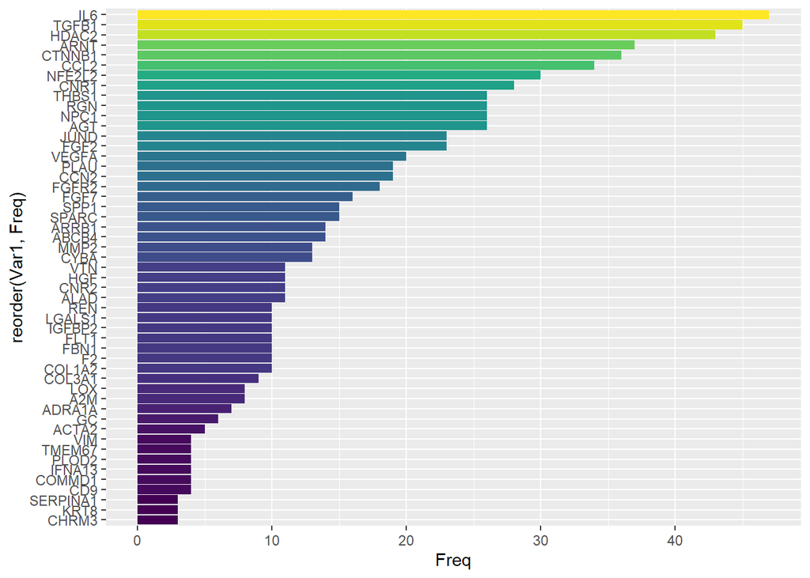

```
## [1] 234
```

```
##   [1] "platelet-derived growth factor receptor-beta signaling pathway"
##   [2] "cannabinoid signaling pathway"
##   [3] "ligand-gated ion channel signaling pathway"
##   [4] "phospholipase C-activating G protein-coupled acetylcholine receptor signaling pathway"
##   [5] "G protein-coupled acetylcholine receptor signaling pathway"
##   [6] "adenylate cyclase-inhibiting G protein-coupled acetylcholine receptor signaling pathway"
##   [7] "acetylcholine receptor signaling pathway"
##   [8] "G protein-coupled serotonin receptor signaling pathway"
##   [9] "ion channel modulating, G protein-coupled receptor signaling pathway"
##  [10] "non-canonical Wnt signaling pathway"
##  [11] "protein kinase B signaling"
##  [12] "vascular endothelial growth factor receptor-1 signaling pathway"
##  [13] "vascular endothelial growth factor signaling pathway"
##  [14] "SMAD protein signal transduction"
##  [15] "type I interferon-mediated signaling pathway"
```

[output cut: 92 more lines]

```
## [1] 107
```

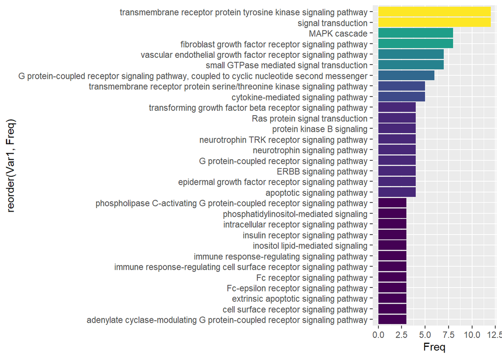

# 4 fin

fin